# Advanced data manipulation in R

From the *Introduction to R* lecture series by

Mikko Vihtakari

Researcher, Institute of Marine Research  
mikko.vihtakari@hi.no

12 February, 2020

> Disclaimer: This is unfinished lecture material. The document has not been peer-reviewed and is likely to contain errors and false statements. **Please do not distribute outside your working group**. The author is not a computer scientist, but a common ecologist.

# Outline

R is a [statistical programming environment](http://www.r-project.org/), and together with its extensions, R enables data manipulation, analysis, graphing and article writing all within the same powerful scientific tool. If used correctly, R can save weeks of tedious data handling compared to a commonly used alternative. Learning R, however, can be a daunting task. **The introduction to R** course framework developed by Dr. Mikko Vihtakari consists of *one-day-long courses* that build upon each other. These courses can be offered flexibly tailored to the needs of the audience.

This is a handout for Advanced data manipulation in R, the third course in the series. You can order the author to give any parts of these lectures or other tailored workshops to your institute. The course consists of four lectures:

1. Creating functions.
2. Looping and regular expressions.
3. Data manipulation II.
4. Data manipulation III.

**Course description:** R offers many powerful methods to manipulate small and large datasets. There are virtually infinite ways to reach the goal, but one method is often shorter, more memory efficient, or more elegant than another. Knowing which method to use in a certain case is confusing and a life-long learning process. Despite this, getting an overview of various methods helps the learning. During this one-day course, you will learn multiple methods needed to manipulate data in R. The course focusses on creating custom functions, regular expressions, merging datasets, the base R looping commands such as the `for` and the `apply` family loops, including the split-apply-combine routine, as well as the methods offered by the `tidyverse` and `data.table` packages. The course is aimed for people who have used R for some time or have taken the previous courses of the *Introduction to R* course framework.

# Lecture 1: Creating functions

Data manipulation in R, or any other programming environment, requires the use of functions each doing their own separate thing with data. The usage of functions in programming is like building a castle out of Lego-bricks. Each brick is a separate entity and can be used multiple times within the construction. When placed on top and by side of each other, the bricks form a larger construction. If one removes one type of brick, the construction can collapse or does not work as it was intended to do. The benefit of using functions instead of long scripts is that your script becomes easier to read, modify and debug. R and its packages have many functions, but the ability to write your own is required for efficient and applied data manipulation. During this lecture, you will learn how to write functions and how to translate your code to functions instead of long repeated pieces of script. There are multiple helpful sites online explaining how to write functions (some of them: [Rich FitzJohn’s and Daniel Falster’s guide for biologists](https://nicercode.github.io/guides/functions/), the [official R manual](https://cran.r-project.org/doc/manuals/R-intro.html#Writing-your-own-functions) and [Hadley Wickham’s tips](http://adv-r.had.co.nz/Functions.html)). Make sure to check those out too when you are writing your functions.

## Conditional statements

Conditional statements are one of the backbones of programming and useful, especially when creating functions. The most used ones are the `if` and `else` statements. These statements function as in many other programming languages. The **`if()`** statement requires a logical test returning a **single** `TRUE` or `FALSE`:

```r
if (LOGICAL TEST) {
  STATEMENT (WHAT TO DO) IF THE TEST PASSES
}
```

It is often required to do something else in cases when the `if` statement does not pass (returns `FALSE`). For this we can use the `else` statement:

```r
if (LOGICAL TEST) {
  STATEMENT (WHAT TO DO) IF THE TEST PASSES
} else {
  STATEMENT (WHAT TO DO) IF THE TEST FAILS
}
```

This can be illustrated by another schematic borrowed from [learn-r.org](https://www.learn-r.org/r-tutorial/if-else-statement.php) (Figure 2)

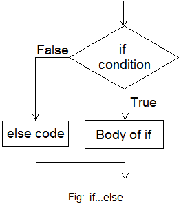

Figure 2: Flowchart of the if-else statement. Source: https://www.learn-r.org/r-tutorial/if-else-statement.php

Multiple if statements can also be chained and nested to form more complex statements:

```r
if (LOGICAL TEST 1) {
  STATEMENT (WHAT TO DO) IF TEST 1 PASSES
} else if(LOGICAL TEST 2) {
  STATEMENT (WHAT TO DO) IF TEST 1 FAILS, BUT TEST 2 PASSES
} else {
  if(LOGICAL TEST 3) {
    STATEMENT (WHAT TO DO) IF TESTS 1 AND 2 FAIL, BUT TEST 3 PASSES
  }
}
```

**Exercise:** Draw a flowchart of the expression above.

Note that in the example above, nothing will be evaluated if tests 1, 2 and 3 fail (all return `FALSE`).

### if statements require a single logical value

The `if` statements require a logical test returning a **single logical value**. Otherwise, R will use the first value in a logical vector and return a warning:

```r
if(c(TRUE, FALSE)) "bla" # Since the statement is a one-liner, we do not need the { }
```

```
## Warning in if (c(TRUE, FALSE)) "bla": the condition has length > 1 and only the
## first element will be used
```

```
## [1] "bla"
```

Logical vectors with length >1 can be made to single logical values using the [`all`](https://stat.ethz.ch/R-manual/R-devel/library/base/html/all.html) and [`any`](https://stat.ethz.ch/R-manual/R-devel/library/base/html/any.html) functions:

```r
all(c(TRUE, TRUE, TRUE)) # all returns TRUE if all elements are TRUE
```

```
## [1] TRUE
```

```r
all(c(TRUE, FALSE, TRUE)) # all returns FALSE if any of the elements is FALSE
```

```
## [1] FALSE
```

```r
any(c(FALSE, FALSE, TRUE)) # any returns TRUE if any of the elements is TRUE
```

```
## [1] TRUE
```

```r
any(c(FALSE, FALSE, FALSE)) # any returns FALSE if all elements are FALSE
```

```
## [1] FALSE
```

### `ifelse()` - a vectorized conditional statement

There is also the function called [`ifelse`](https://stat.ethz.ch/R-manual/R-devel/library/base/html/ifelse.html), which is a vectorized alternative to the `if` and `else` statements. Using this function for vectors, such as data frame columns, creatly simplifies and speeds up your code, but the function is [inefficient for very large data (millions of rows)](https://stackoverflow.com/questions/34005423/is-if-faster-than-ifelse?noredirect=1&lq=1), because both alternatives are [separately evaluated for every vector element](https://stackoverflow.com/questions/16275149/does-ifelse-really-calculate-both-of-its-vectors-every-time-is-it-slow). We will go through more efficient ways of applying logical statements to big-data during the Data manipulation III lecture. An example of applying the vectorized `ifelse` function over data frame columns:

```r
x <- data.frame(variable = rep(c("a", "b"), 3), value = rnorm(6, 5, 2))

# if variable == a, multiply value by 4, else return value:
x$new.value <- ifelse(x$variable == "a", 4 * x$value, x$value)

x
```

```
##   variable    value new.value
## 1        a 4.165342 16.661368
## 2        b 5.493049  5.493049
## 3        a 8.865206 35.460823
## 4        b 9.449296  9.449296
## 5        a 6.724738 26.898954
## 6        b 6.561489  6.561489
```

## Control function execution

Sometimes there is a need to control the function execution in conjunction with `if else` statements. The [`stop`](https://stat.ethz.ch/R-manual/R-devel/library/base/html/stop.html), [`warning`](https://stat.ethz.ch/R-manual/R-devel/library/base/html/warning.html) and [`message`](https://stat.ethz.ch/R-manual/R-devel/library/base/html/message.html) functions are made for this purpose. For example, consider a situation where you make a function, which requires a data frame to be evaluated correctly, but the user feeds in a vector:

```r
x <- 1:2 # create a numeric vector

# the stop function stops the evaluation and returns an error specified inside the function call:
if(!is.data.frame(x)) stop("x has to be a data frame")

# the warning function allows evaluation, but returns a warning:
if(!is.data.frame(x)) warning("x has to be a data frame")

# the message function allows evaluation and returns a message:
if(!is.data.frame(x)) message("x has to be a data frame")
```

[Use these control functions modestly, though](https://www.r-bloggers.com/a-warning-about-warning/), as unnessesary warnings and messages can sometimes be annoying when using over-talkative functions inside other functions. Many times there is no reason to stop the evaluation due to a small input inconsistency. Equally many times there is no need to return a warning, but stop the evaluation, return a message or remain silent. If you know that the warnings and messages returned by a function do not influence your output, you can suppress them using the [`suppressWarnings`](https://stat.ethz.ch/R-manual/R-devel/library/base/html/warning.html) and [`suppressMessages`](https://stat.ethz.ch/R-manual/R-devel/library/base/html/message.html) functions. You can also use the [`print`](https://stat.ethz.ch/R-manual/R-devel/library/base/html/print.html) function to return important information during evaluation that does not influence your output otherwise (demonstrated later during this course).

### The `try` function to avoid stopping evaluation

Note that in the example above, the code could not be evaluated in this markdown document, because the [`stop`](https://stat.ethz.ch/R-manual/R-devel/library/base/html/stop.html) function stops the evaluation. The [`try`](https://stat.ethz.ch/R-manual/R-devel/library/base/html/try.html) function has been developed to avoid such glitches. The function evaluates an expression and returns the value defined by the expression if the expression does not stop the evaluation (i.e. does not return an error). Otherwise, the function returns the error as a character string.

```r
try(1 + 1)
```

```
## [1] 2
```

```r
try(stop("You can't stop me!"))
```

```
## Error in try(stop("You can't stop me!")) : You can't stop me!
```

The `try` function is a [wrapper](https://en.wikipedia.org/wiki/Wrapper_function) of the [`tryCatch()`](https://stat.ethz.ch/R-manual/R-devel/library/base/html/conditions.html), which is more flexible but also slightly more difficult to use and understand.

## Writing functions

Now that you have learned to control expressions inside functions, you are ready to learn the (simple) process of making custom functions in R. Functions are defined using the fittingly named `function` function. Custom functions are assigned to an object, which becomes the name of your function:

```r
your_function <- function(ARGUMENTS) {
  FUNCTION STATEMENTS (I.E. WHAT THE FUNCTION SHOULD DO)
}
```

Naming of the object follows the standard object naming in R, but there are [good and bad practices in naming your functions](http://r-pkgs.had.co.nz/style.html). As a concrete example, we’ll make a function, which returns the `n`th element from each element of a list

```r
select_element <- function(x,n) sapply(x, "[", n) # No { } needed because the statement is a one-liner

lst <- list(numeric = 1:3,
            datetime = as.Date(1:3, origin = Sys.time()),
            character = letters[1:3]
)

select_element(x = lst, n = 3)
```

```
##   numeric  datetime character
##       "3"   "18307"       "c"
```

**Excercise E1.1**: The formula for the standard error of the mean (SE) is $SE = \frac{\sigma}{\sqrt{n}}$, where $\sigma$ is the standard deviation and $n$ the number of samples. Write a function, called `se`, which calculates SE for a numeric vector containing `NA`s

### What happens in a function, stays in the function

Note that an important feature of functions is that **what happens inside a function, stays in the function** unless you **return it using the explicit `return`** command or as **the last line of the function**. This behavior stems from the fact that functions in programming are generalized from mathematics and is a hugely useful feature saving RAM and making computers to perform as well as they do. As an example, in mathematics, we can state that the variable y is a function of the variable x ($y = f(x)$). The $f(x)$ part can be whatever that returns a number. For example, $x + 2$, in which case y is consequently 2 units higher than x. The $f(x)$ can also be an equation requiring multiple lines to calculate the value of y given the value of x. In any case, this mathematical function returns an answer regardless of how complicated it is (remember that also “not possible to reach an answer” is an answer, for example when dividing by 0). The point is that the answer comes out from the function and anything else that happens within the function, stays there and is not returned. Computers, including R, follow a similar logic:

```r
my_fun <- function(x) {
  x + 1
  x + 2
}

my_fun(1) # Returns the result from the last line of the function. This is default behavior.
```

```
## [1] 3
```

```r
my_fun <- function(x) {
  return(x + 1)
  x + 2
}

my_fun(1) # Returns the result from the first line of the function because it is explicitly stated using the return command
```

```
## [1] 2
```

```r
my_fun <- function(x) {
  c(x + 1, x + 2)
}

my_fun(1) # To return both calculations, one can make a vector out of them (any other data type also works)
```

```
## [1] 2 3
```

```r
my_fun <- function(x) {
  out <- c(x + 1, x + 2)
}

my_fun(1) # Returns nothing because we assigned to an object, which we did not ask to return
```

**Exercise E1.2**: How could we make the last example to return the value?

### Conditional statements and execution controls within functions

While each function, ideally, should do one thing, the real-world applications can get long and complicated. Conditional statements are needed to both control the execution flow and to keep the users, who have not written the function, using the function as intended. Below you see one of my work-horse functions, which I use to look at [colors](https://www.nceas.ucsb.edu/~frazier/RSpatialGuides/colorPaletteCheatsheet.pdf) in a character vector, as an example.

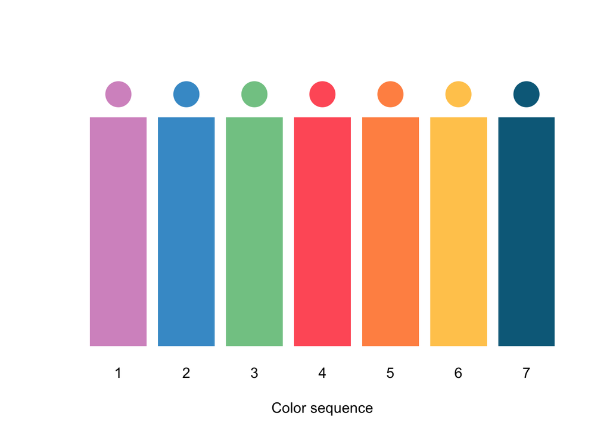

```r
check_cols <- function(cols) {

  if(!is.character(cols)) stop("cols has to be a character vector") # Stop execution if the cols argument isn't a character vector

  if (is.null(names(cols))) { # Add labels if cols is not a named vector
    labs <- seq_along(cols)
  } else { # Add labels if cols is a named vector
    labs <- paste0(names(cols), "\n[", seq_along(cols), "]")
  }

  # Make bars
  mp <- barplot(rep(1, length(cols)), yaxt = "n",
                col = cols, border = NA, names.arg = labs, xlab = "Color sequence", ylim = c(0,1.2))
  # Add points above the bars
  points(mp, rep(1.1, length(cols)), col = cols, pch = 16, cex = 4)
}

example_colors <- c("#D696C8", "#449BCF", "#82C893", "#FF5F68", "#FF9252", "#FFC95B", "#056A89")

check_cols(example_colors)
```

Note how the function counter-intuitively returns a plot that consists of two lines of code. This is because the function returns a [graphic device](https://stat.ethz.ch/R-manual/R-devel/library/grDevices/html/Devices.html), which supports multiple lines of code, but the device itself is returned from the last line of the function.

**Exercise E1.3**: Write a function which returns a factor, if the input is a character vector, an integer vector if the input only has whole numbers, a numeric vector if the input contains a fraction and otherwise returns an error telling that the input should be a vector containing characters or numbers.

### Reformulating script as functions

The process of learning to write functions involves the ability to translate your existing R script to a script that does the same but uses custom functions instead. The point is not to translate everything to functions, even though this is certainly possible, but to translate the parts that are often repeated, error-prone, difficult to understand, or could be useful in future applications. Under is a piece of R code, which can be simplified by defining custom functions. Copy this code to a new R script in RStudio and try to translate it to a function.

**Exercise E1.4**

**Script to translate**

The following code creates a synthetic [length-weight relationship](https://www.fishbase.se/manual/fishbasethe_length_weight_table.htm) ($Weight = a \times Length^b$) for a species with `a = 0.01` and `b = 3` using a normal distribution with coefficient of variation of 15% (`CV`) to add noise into the relationship. The script then estimates `a` and `b` using a linear approximation and plots the relationship. Make a function which asks for minimum and maximum size of a species as well as the `a`, `b` and `CV` parameters and plots the relationship.

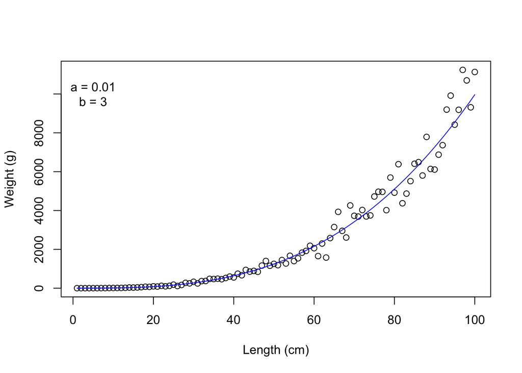

```r
x <- data.frame(length = 1:100,
                weight = mapply(rnorm, n = 1, mean = 0.01*(1:100)^3, sd = (0.01*(1:100)^3)*0.15)
)

mod <- lm(log(weight) ~ log(length), data = x)

plot(x$length, x$weight, xlab = "Length (cm)", ylab = "Weight (g)")
lines(x$length, exp(predict(mod)), col = "blue")
text(x = 5, y = 0.01*100^3,
     paste0("a = ", round(exp(coef(mod)[1]), 2), "\n", "b = ", round(coef(mod)[2], 2))
)
```

You can find one suggestion as an answer to the exercise from the Answers to exercises. Remember that programming is like talking a language and there is rarely one ultimate correct way of doing things.

## Documenting functions

One of the strengths of R is the focus on writing adequate documentation for any functions published in CRAN. It is a good practice to follow the [CRAN standards](https://cran.r-project.org/doc/manuals/r-release/R-exts.html) when writing your functions. Documenting any slightly complicated function may take time when writing the documentation, but, on the other hand, it saves time because it forces you to think the logic behind your function and gives you a chance to remember what you did a couple of months later. RStudio compiles R packages for you (covered during a separate course) and uses the [roxygen2](https://cran.r-project.org/web/packages/roxygen2/vignettes/roxygen2.html) language to generate function documentation you see in the help-sheets (the `?` command). How to write such documentation is [described well by the RStudio team](https://cran.r-project.org/web/packages/roxygen2/vignettes/rd.html). The `roxygen2` documentation is written with `#'` at the beginning of each line and often consists of following elements:

```r
#' @title The title of your function. Required. The tag can be omitted in which case the first line beginning with #' will be evaluated as the title
#' @description Description of the function. It should be more detailed than the title and should not repeat the wording in the title. Analogous to the abstract section in scientific articles, but shorter. Required. The tag can be omitted in which case the second line beginning with #' will be evaluated as the title
#' @param ARGUMENT_NAME1 Description of the argument 1. Required. The tag cannot be omitted.
#' @param ARGUMENT_NAME2 The param field should be repeated for each function argument, i.e. the things you put inside the brachets in function( )
#' @details A detailed description of the function. Analogous to the material and methods section in scientific articles. It can be long (but does not have to be). Not required.
#' @return Describe what the function returns. Not required.
#' @import PACKAGE_NAME1 PACKAGE_NAME2 (which external packages the function depends on, i.e. should import when loaded. Not required. Alternatively:)
#' @importFrom PACKAGE_NAME FUNCTION_NAME (which functions from which external packages the function depends on. Alternative to @import. Not required.)
#' @author The author of the function. Functions are meant to be borrowed by the open-source community. With this field, you'll make the borrower's life easier as they do not need to track down the person who wrote the function (a citation is required whenever you modify someone else's intellectual property.)
#' @export (This is required to export the function to the package NAMESPACE when compiling a package using RStudio)
```

Note that RStudio contains a Roxygen Quick Reference Sheet (Help -> Roxygen Quick Reference). Under is an example of documentation for the `check_cols` function:

```r
#' @title Plot color vector to inspect the colors visually
#' @description This function makes a plot showing the colors in a character vector
#' @param cols a character vector containing accepted R \link[grDevices]{colors}
#' @return returns a base R \link[graphics]{plot} with the colors given in \code{cols} argument
#' @author Mikko Vihtakari
#' @export
```

**Exercise E1.3**

## Debugging functions

The art of debugging, i.e. finding mistakes in your code, becomes easier when writing your code as functions instead of a long script. This is because the functions are based on arguments, which hopefully are not used in your workspace, and because if you make a mistake, the results tend to be consistently wrong. Fixing bugs in functions is easier than correcting bugs in several places in a script. The most important skill while debugging is having the patience to **read the error messages R returns and think what they imply**. There are multiple ways to debug in [R and RStudio](https://adv-r.hadley.nz/debugging.html) many of which are [more sophisticated](https://support.rstudio.com/hc/en-us/articles/205612627-Debugging-with-RStudio) than the methods used here. Here we learn the simplest methods for transparency. Consider a function which throws an error when the input value is 0 and returns the fraction specified by the input value otherwise:

```r
f <- function(x) {
  if (x == 0) {
    stop ("x cannot equal 0")
  } else {
    1/x
  }
}
```

### Debugging in the global environment

Now, let’s make the function to return an error (write `f(0)` in R console). The most primitive, and useful for functions without too many arguments, form of debugging is to walk through the function using the parameters which cause the error (note that “parameters” and “arguments” are used as synonyms here). In a way this is an inverse operation of what we learned in the Reformulating scripts as functions section:

```r
x <- 0

if (x == 0) {
  stop ("x cannot equal 0")
} else {
  1/x
}
```

By running the script above line-by-line, you would quickly learn that the error comes because the `if` statement asks to stop the funciton evaluation when `x = 0`. This method is tidious for long functions, however, and there are better alternatives. One major problem in debugging in the global environment is that everything you do here gets naturally stored in the global environment and will interfere with any code you you evaluate. A trick to avoid this is to write short scripts for each separate operation instead of those monster-scripts many may be used to. Once you have debugged your function, you can just clear the workspace and run the script to where you were using `Ctrl + Shift + B`.

### `traceback`

The [`traceback`](https://stat.ethz.ch/R-manual/R-devel/library/base/html/traceback.html) function can be used to find out where in the function the error occurs:

```r
traceback(f(0))

## Error in f(0) : x cannot equal 0
##  4. stop("x cannot equal 0")
##  3. f(0)
##  2. .traceback(x)
##  1. traceback(f(0))
```

Now we could go to the function code and find the place where `stop("x cannot equal 0")` is stated. That is where the error occurs.

In real-world applications, the bugs in functions are often nested within a long chain of functions, however. Let’s demonstrate this using a simple example by nesting multiple functions within each other with the original “trouble-child” causing the actual error:

```r
f2 <- function(x) {
  f(x) + 2
}

f3 <- function(x) {
  f2(x) + 3
}

f3(0)

## Error in f(x) : x cannot equal 0
##  4. stop("x cannot equal 0")
##  3. f(x)
##  2. f2(x)
##  1. f3(0)
```

We notice: 1) RStudio automatically uses `traceback` to help us to find out where the error occurs. 2) From the traceback syntax, we notice that the function walks through the chain of functions for us. First `f3(0)` is called without errors, then `f2(x)` again without errors, and finally `f(x)` returning the error. Now, we can head back to `f` code and locate the line with `stop("x cannot equal 0")` where the error occurs. Note, however, that the error is ultimately caused by our `if` statement. Something that you cannot find out without looking at the function code.

The [`browser`](https://stat.ethz.ch/R-manual/R-devel/library/base/html/browser.html) function is hugely useful in such cases when debugging. Let’s modify the code for `f3` placing a browser call in it:

```r
f3 <- function(x) {
  browser()
  f2(x) + 3
}
```

### Interactive debugging

If we run `f3(0)` again, we notice that RStudio jumps into a browser mode for **interactive debugging**. This applies a graphical code interface in the script editor panel and also the R console. Both of these show the same thing. Here we enter the function environment allowing us to see what happens in that environment (remember that functions are evaluated in a separate environment). Write `n` in the console and hit enter (or click the “Continue” button in RStudio) to get to the next call in the function hierarchy. To quit the debugging write `Q` and hit enter (or click the “Stop” button):

```r
f3(0)

Called from: f3(0)
Browse[1]> x
[1] 0
Browse[1]> n
debug at #3: f2(x) + 3
Browse[2]> x
[1] 0
Browse[2]> n
Error in f(x) : x cannot equal 0
> f3 <- function(x) {
+   browser()
+   f2(x) + 3
+ }
> f3(0)
Called from: f3(0)

Browse[1]> x # Call for x inside f3() and see the value
[1] 0

Browse[1]> n
debug at #3: f2(x) + 3
Browse[2]> x
[1] 0

Browse[2]> n
Error in f(x) : x cannot equal 0
```

By using the `browser`, we essentially found out the same thing than using `traceback` with the exception that we could play around inside the function environment. Consequently, this method combines the strengths of `traceback` and debugging in the global environment, but takes some time to get used to.

### Debugging complicated functions

**Answer**

```r
fun <- function(x) {

  if(is.character(x)) {
    factor(x)
  } else if(all(x%%1==0)) {
    as.integer(x)
  } else {
    as.numeric(x)
  }

}
```

# Lecture 2: Looping and regular expressions

## Looping

R is an immensely powerful data manipulation tool compared to the commonly used alternatives that do not require knowledge in programming. While there are better alternatives these days (covered during the lectures 3 and 4), perhaps the most used applied base R data manipulation routine involves splitting your dataset based using a set of keys (often columns that group data), applying a function, which does the data manipulation task over the grouped data and combining the grouped data to a larger dataset again. The split-apply-combine routine can be surprisingly memory-efficient because your computer does not store the operations that happen inside the function in RAM (remember what happens in a function, stays in the function). “Surprisingly memory-efficient”, because in interpreted languages like R, [vectorization](https://en.wikipedia.org/wiki/Array_programming) generally is the fastest and most efficient way to handle data, and the split-apply-combine routine splits your data against the idea of vectorization as explained above. Now that you have learned to write functions, we can see how to loop them over your data and eventually how to use the split-apply-combine routine to manipulate your data.

### Load example data

We will use real IMR database data as an example for looping. You can find the downloaded files in the `/Data` folder, but if you want to download the data yourself, you will need the [`RstoxData`](https://github.com/StoXProject/RstoxData) package installed on your computer. The easiest way to install the package on Windows computers is to download the binary (.zip for Windows, .tgz for Unix) from [here](https://github.com/StoXProject/RstoxData/releases), decompress it and place the folder in your R library folder. Use `.libPaths()` to find the correct folder(s). Note that you will need the IMR’s intranet to follow the example. First, we use the [IMR’s API system](https://confluence.imr.no/display/API/Biotic+V3+API+documentation) to find an .xml file containing the data from EggaNord 2019 survey. The easiest way to locate these files is to use the [Dataset Explorer](https://datasetexplorer.hi.no/apps/datasetexplorer/v2/navigation). The official name for the EggaNord survey is “Norwegian Sea continental slope NOR deep-sea fish cruise in autumn”. Open this folder and navigate to year 2019. Further navigate to the cruise number. Note that you could download the .xml file here by clicking “Download” by the side of the Biotic text. We, however, want to find a path, which we can use directly in R to download the file. Click “Open” by the Cruiseoverview text. Next click “View” by the green Biotic text and fish symbol on the right side of the page. Here you will see Data url, which does not work as such, because it contains HTML formatting errors ( should be written as `%20` in URLs; also the Norwegian letters are formatted wrong). Click the link, which will open a new tab. Copy this correctly formatted link to the [`download.file`](https://stat.ethz.ch/R-manual/R-devel/library/utils/html/download.file.html) function as demonstrated under:

**R code to download data from the IMR database**

```r
download.file("http://tomcat7.imr.no:8080/apis/nmdapi/biotic/v3/Leiefart%C3%B8y/2019/Arni%20Fridriksson_TFNA/2019860/dataset?version=3.0", destfile = "Data/EggaN19.xml")

library(RstoxData) # Load the package to read NMD data
library(data.table) # Required to manipulate the files

dt <- RstoxData::readXmlFile("Data/3 EggaN19.xml") # Open the xml file
dt <- RstoxData::mergeDataTables(dt, tableNames = c("fishstation", "catchsample", "individual")) # Merge hierarchical data tables so that they are easier to work with

dt[c("fishstation", "catchsample", "individual")] <- # Remove empty columns
  lapply(dt[c("fishstation", "catchsample", "individual")], function(k) {
    k[, which(unlist(lapply(k, function(x) !all(is.na(x))))), with = FALSE]
  })

save(dt, file = "Data/3 EggaN19.rda") # Save in Rdata format
```

You can now load the example file regardless followed you the example above or not:

```r
load("Data/3 EggaN19.rda")
```

### The apply family of functions

All of the functions in the apply family apply a function over a data structure. The `apply` function accepts data frames, matrices or arrays; the `lapply` accepts and exports lists; and finally the `mapply` applies a function over multiple lists or vectors. Even though these functions operate on different data structures, it does not mean that you could not use, say, data frames in the `lapply` function (explained in detail under). When and where to use these functions is a long learning process, but generally `lapply` is the most versatile solution. Here we go through some applied uses for each function.

Note that all apply family functions operate using similar syntax: `*apply(X, FUNCTION, ...)`, where `X` is the data structure, `FUNCTION` the function to be used, and `...` extra arguments to `FUNCTION` or `*apply`. The function can be fed in as an object name (`sum` as an example), if it only has one variable; as `function(k) sum(k)` (where `k` is the piece of looped data coming from `X`), which works also for multiple arguments and custom functions such as `function(k) data.frame(sum = sum(k))` as an example. This idea becomes more clear when you look at the examples under.

### Apply a function over a data frame

The `apply` function operates on data frame and matrix rows or columns: `apply(MATRIX, MARGIN, FUNCTION)`. Where `MATRIX` is the object name of a matrix or data frame, `MARGIN` `1` (rows), `2` (columns) or `c(1, 2)` (both), and `FUNCTION` the function to be applied. For example:

```r
x <- data.frame(a = rnorm(10, 4, 2), b = rnorm(10, 10, 5), c = rnorm(10, 20, 5))

apply(x, 1, sum) # row sums
```

```
##  [1] 30.74040 25.36060 32.61178 34.89501 34.61411 40.39689 43.49800 31.41751
##  [9] 45.44266 33.49229
```

```r
apply(x, 2, mean) # column means
```

```
##         a         b         c
##  4.069406 10.321177 20.856342
```

```r
apply(x, 2, sd) # column standard deviations
```

```
##        a        b        c
## 2.287389 4.697634 4.521312
```

```r
apply(x, 2, function(k) k-mean(k)) # deviations from column means
```

```
##                a          b          c
##  [1,] -1.7976150  1.9934996 -4.7024132
##  [2,] -1.6135501 -7.0340614 -1.2387164
##  [3,] -1.2645613 -2.6734934  1.3029139
##  [4,]  0.7537456 -2.2156863  1.1100267
##  [5,]  0.5425557 -6.9219285  5.7465572
##  [6,] -0.1538370  3.3432916  1.9605056
##  [7,]  1.6486531  6.2014972  0.4009283
##  [8,] -4.0977536  5.8716443 -5.6033089
##  [9,]  2.1650082  0.8685842  7.1621457
## [10,]  3.8173545  0.5666527 -6.1386389
```

### The split-apply-combine routine

The split-apply-combine routine consists of utilizing three functions: [`split`](https://stat.ethz.ch/R-manual/R-patched/library/base/html/strsplit.html), which splits the data frame to a list of grouped data frames; [`lapply`](https://stat.ethz.ch/R-manual/R-devel/library/base/html/lapply.html), which applies the data manipulation function; and finally the [`do.call`](https://stat.ethz.ch/R-manual/R-devel/library/base/html/do.call.html) & [`rbind`](https://stat.ethz.ch/R-manual/R-devel/library/base/html/cbind.html) combination that is used to combine the list of grouped data frames into a compiled manipulated data frame.

Let’s use our example dataset from the EggaNord survey in 2019 to calculate average length and standard deviation for each species in the catch. First, we’ll use the `split` function to split the individual based data frame into a list of data frames grouped by species:

```r
split.ind.dt <- split(dt$individual, dt$individual$commonname, drop = TRUE)
```

Then we will write a script to calculate mean length, standard deviation, and number of observations for the first data frame in the list:

```r
data <- split.ind.dt[[1]]

data.frame(species = unique(data$commonname), length.mean = mean(data$length, na.rm = TRUE),
           length.sd = sd(data$length, na.rm = TRUE), length.n = sum(!is.na(data$length)))
```

```
##         species length.mean  length.sd length.n
## 1 båndålebrosme        0.26 0.03905125        3
```

Now that we can express the calculation for one of the species, we can translate the script into a function:

```r
calc_mean_length <- function(data) {
  data.frame(species = unique(data$commonname), length.mean = mean(data$length, na.rm = TRUE),
             length.sd = sd(data$length, na.rm = TRUE), length.n = sum(!is.na(data$length)))
}
```

We then apply this function over the list of data frames grouped by species:

```r
out <- lapply(split.ind.dt, calc_mean_length)
```

Finally, we combine the splitted data frames into one compiled one using the [`do.call`](https://stat.ethz.ch/R-manual/R-devel/library/base/html/do.call.html) and [`rbind`](https://stat.ethz.ch/R-manual/R-devel/library/base/html/cbind.html) functions. While at it, we can sort the compiled data frame by mean length and plot it.

```r
mean.lengths <- do.call(rbind, out)

mean.lengths <- mean.lengths[order(-mean.lengths$length.mean),] # Order the data frame
mean.lengths$species <- factor(mean.lengths$species,
                               levels = mean.lengths$species) #Order for ggplot2

mean.lengths <- rapply(object = mean.lengths, f = round,
                       classes = "numeric", how = "replace",
                       digits = 3) # round numerical values using rapply for a nicer table

head(mean.lengths)
```

```
##                 species length.mean length.sd length.n
## blålange       blålange       0.970        NA        1
## blåsteinbit blåsteinbit       0.740     0.206       37
## torsk             torsk       0.732     0.151      128
## gråsteinbit gråsteinbit       0.695     0.064        2
## brosme           brosme       0.680        NA        1
## gråskate       gråskate       0.663     0.298       12
```

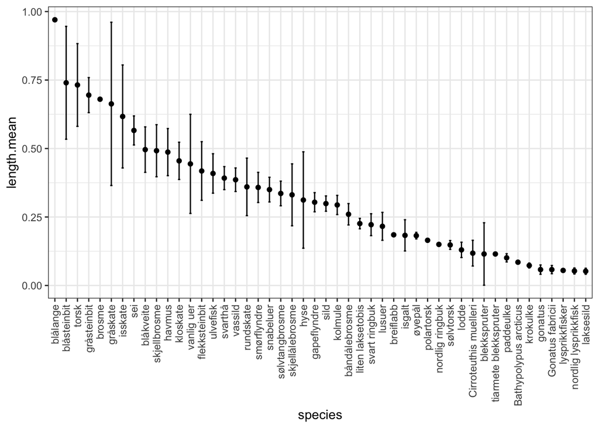

```r
library(ggplot2)

ggplot(mean.lengths,
       aes(x = species, y = length.mean, ymin = length.mean - length.sd,
           ymax = length.mean + length.sd)) +
  geom_errorbar(width = 0.2) +
  geom_point() +
  theme_bw() +
  theme(axis.text.x = element_text(angle = 90, vjust = 0.5, hjust = 1))
```

### Other lapply based functions

#### sapply

The `sapply` function is a “user-friendly” wrapper for `lapply`. It is often used to return a named vector instead of a list simplifying code in certain situations:

```r
sapply.output <- sapply(split.ind.dt, function(k) mean(k$length))
head(sapply.output)
```

```
##         båndålebrosme Bathypolypus arcticus             blåkveite
##             0.2600000             0.0850000                    NA
##              blålange           blåsteinbit          blekkspruter
##             0.9700000             0.7402703             0.1150000
```

#### tapply

The `tapply` function can be used to do the same calculation we did with `sapply` without having to split first:

```r
tapply.output <- tapply(X = dt$individual$length, INDEX = dt$individual$commonname, FUN = mean)
all(sapply.output == tapply.output, na.rm = TRUE) # The values are equal to the sapply method
```

```
## [1] TRUE
```

#### by

There is also the the `by` function which combines the “split-apply” part of the routine still requiring a separate “combine” part:

```r
out <- by(dt$individual, INDICES = dt$individual$commonname, FUN = calc_mean_length)
head(do.call(rbind, out))
```

```
##                                     species length.mean  length.sd length.n
## båndålebrosme                 båndålebrosme   0.2600000 0.03905125        3
## Bathypolypus arcticus Bathypolypus arcticus   0.0850000         NA        1
## blåkveite                         blåkveite   0.4964358 0.08340365    11328
## blålange                           blålange   0.9700000         NA        1
## blåsteinbit                     blåsteinbit   0.7402703 0.20629653       37
## blekkspruter                   blekkspruter   0.1150000 0.11366618        6
```

#### rapply

The `rapply` function can used to apply modifications to certain vector classes in a data structure. For example, how we used it to round all numeric columns in the split-apply-combine demonstration. The function can also be used to convert vector classes:

```r
str(mean.lengths)
```

```
## 'data.frame':    48 obs. of  4 variables:
##  $ species    : Factor w/ 48 levels "blålange","blåsteinbit",..: 1 2 3 4 5 6 7 8 9 10 ...
##  $ length.mean: num  0.97 0.74 0.732 0.695 0.68 0.663 0.617 0.566 0.496 0.492 ...
##  $ length.sd  : num  NA 0.206 0.151 0.064 NA 0.298 0.188 0.053 0.083 0.095 ...
##  $ length.n   : int  1 37 128 2 1 12 52 18 11328 7 ...
```

```r
str(rapply(object = mean.lengths, f = as.character, classes = "factor", how = "replace"))
```

```
## 'data.frame':    48 obs. of  4 variables:
##  $ species    : chr  "blålange" "blåsteinbit" "torsk" "gråsteinbit" ...
##  $ length.mean: num  0.97 0.74 0.732 0.695 0.68 0.663 0.617 0.566 0.496 0.492 ...
##  $ length.sd  : num  NA 0.206 0.151 0.064 NA 0.298 0.188 0.053 0.083 0.095 ...
##  $ length.n   : int  1 37 128 2 1 12 52 18 11328 7 ...
```

### Applying a function over multiple data structures

The `mapply` function is one of the most powerful ones in base R, but also equally difficult to use and understand. Many applications of `mapply` can appear black-magic, but also considerably shorten the required code. The function operates as follows: `mapply(FUNCTION, DATA1, DATA2, ..., DATAn, MoreArgs = list(ARGS))`, where `FUNCTION` is the function to be used, `DATA1` to `DATAn` the multiple data objects, and `ARGS` a list of arguments to `FUNCTION`. Note that `FUNCTION` has to have equally many arguments as there are specified `DATA` objects. As a simple example, let’s repeat numbers 1 to 4 equally many times. Note how we utilize the `rep` function arguments `x`, `times`, `length.out` and `each`:

```r
mapply(rep, x = 1:4, times = 1:4)
```

```
## [[1]]
## [1] 1
##
## [[2]]
## [1] 2 2
##
## [[3]]
## [1] 3 3 3
##
## [[4]]
## [1] 4 4 4 4
```

```r
mapply(rep, x = 1:4, length.out = 1:4) # The result is equal to above
```

```
## [[1]]
## [1] 1
##
## [[2]]
## [1] 2 2
##
## [[3]]
## [1] 3 3 3
##
## [[4]]
## [1] 4 4 4 4
```

```r
mapply(rep, x = 1:4, each = 1:4) # The result is equal to above
```

```
## [[1]]
## [1] 1
##
## [[2]]
## [1] 2 2
##
## [[3]]
## [1] 3 3 3
##
## [[4]]
## [1] 4 4 4 4
```

The `mapply` function can be used to summarise values from multiple data frames. Under we use the different hierarchies in NMD data format to calculate average catch weight and number of fish as well as the length parameters we calculated for the individual data above:

```r
calc_mean_params <- function(stn, ind) { # Define the function

  data.frame(species = unique(stn$commonname),
             cweight.mn = mean(stn$catchweight, na.rm = TRUE),
             ccount.mn = mean(stn$catchcount, na.rm = TRUE),
             length.mn = mean(ind$length, na.rm = TRUE),
             length.sd = sd(ind$length, na.rm = TRUE),
             length.n = sum(!is.na(ind$length))
  )
}

tmp <- dt$catchsample # Remove the species that were not length measured
tmp <- tmp[tmp$commonname %in% dt$individual$commonname,]

split.stn <- split(tmp, tmp$commonname, drop = TRUE)
split.ind <- split(dt$individual, dt$individual$commonname, drop = TRUE)

out <- mapply(calc_mean_params, stn = split.stn, ind = split.ind, SIMPLIFY = FALSE)

mapply.output <- do.call(rbind, out)
rownames(mapply.output) <- 1:nrow(mapply.output)

head(mapply.output)
```

```
##                 species  cweight.mn ccount.mn length.mn  length.sd length.n
## 1         båndålebrosme  0.08833333  1.000000 0.2600000 0.03905125        3
## 2 Bathypolypus arcticus  0.23000000  1.000000 0.0850000         NA        1
## 3             blåkveite 98.82094638 88.516908 0.4964358 0.08340365    11328
## 4              blålange  3.49000000  1.000000 0.9700000         NA        1
## 5           blåsteinbit 10.73138095  1.761905 0.7402703 0.20629653       37
## 6          blekkspruter  0.37550000  1.500000 0.1150000 0.11366618        6
```

Note that `mapply` is, however, less powerful than the data manipulation methods provided by the `data.table` and `tidyverse` packages. Consequently, no more effort is put in learning this method. The `mapply` function is irreplaceable in some very specific applied cases often involving advanced plotting (covered during the *Designing information graphics with R* course). Otherwise, the function can be replaced by better, faster and easier-to-use alternatives (covered later during this course).

### For loops

When working with larger datasets, computer performance and the time it takes to manipulate data often become a concern. One way of doing the same operation can be hundreds of times faster than another. It is surprisingly difficult to make “rules of thumb” that hold for every situation because the required operations in applied data-manipulation vary wildly. We try to generalize anyways using the philosophy that “the exception confirms the rule”: 1) writing something new to RAM costs time. Each time you assign outside functions in base R, you end up writing something into RAM. 2) `for` loops work on the basis of repeated assignments to RAM, and consequently can be slower than `lapply` loops. 3) Writing a quick `for` loop is more difficult than writing a quick `lapply` loop for people without education in programming and computer science. 4) Therefore, a good rule of thumb for us non-computer scientists is to use the split-apply-combine routine instead of `for` loops in data manipulation (an even better alternative is to use the `data.table` or `dplyr` methods that have been optimized for efficient data manipulation). 5) `for` loops are appropriate when you *have to* assign repeatedly and therefore you should learn to use them.

For loops function similarly to lapply loops with the exeption that they do not apply a function over data. You specify an object name which will be sequentially looped over a specified sequence in the `for` function arguments. The function then loops a statement over the sequence:

```r
for(VAR in SEQ) {
  # note that while VAR and SEQ can be whatever, in has to be exactly as it is stated here.
  STATEMENT (I.E. WHAT SHOULD BE DONE)
}
```

As an example, let’s calculate the [factorial](https://en.wikipedia.org/wiki/Factorial) $5!$

```r
fac <- 5
for(i in 4:1) {
  print(i) # to illustrate that i is looped over 4:1
  fac <- fac*i
}
```

```
## [1] 4
## [1] 3
## [1] 2
## [1] 1
```

```r
fac
```

```
## [1] 120
```

```r
fac == factorial(5) # The result is correct
```

```
## [1] TRUE
```

# Lecture 3: Regular expressions and tidyverse

## Regular expressions

[A regular expression](http://stat.ethz.ch/R-manual/R-devel/library/base/html/regex.html) is a pattern that provides means to specify and recognize strings of text. Regular expressions are run on the background when you search for something with your computer. Now that you are learning to program, you just need to learn to write these strings without using the inbuild search-engine in your operating system. The concept is probably not familiar for people, who have not studied programming, while people with programming experience can apply their previous expertise: [regex (regular expressions)](https://stat.ethz.ch/R-manual/R-devel/library/base/html/regex.html) is its own language and R accepts [POSIX 1003.2](http://www.zytrax.com/tech/web/regex.htm) and [Perl-like](https://perldoc.perl.org/perlre.html#Regular-Expressions) regular expressions.

Regular expressions are confusing for most of us, but luckily there is plenty of help online. One of [the most helpful sites is regex101](https://regex101.com/), where you can paste any text and see how the regular expressions you type target different parts of your strings. Also [`?regex`](https://stat.ethz.ch/R-manual/R-devel/library/base/html/regex.html) is worth taking a look at. A [regular expression cheat sheet prepared by Ian Kopacka](https://www.rstudio.com/wp-content/uploads/2016/09/RegExCheatsheet.pdf) is also a helpful source.

Let’s start by playing around with a string that has many mistakes to be replaced. You can follow this exercise using Regex101 if you want.

```r
x <- c("Reg_ular", "Exp.7.ressions", "can-be", "uSED", "to", "MAt_ch7","&", "6modify", "REGular", "pat_terns")
```

**`grep`** can be used to match patterns

```r
grep("Reg", x)
```

```
## [1] 1
```

```r
grep("Reg", x, value = T)
```

```
## [1] "Reg_ular"
```

```r
grep("Reg", x, value = T, ignore.case = T)
```

```
## [1] "Reg_ular" "REGular"
```

**`gsub`** and **`sub`** are used to remove characters

```r
gsub("_", "", x)
```

```
##  [1] "Regular"        "Exp.7.ressions" "can-be"         "uSED"
##  [5] "to"             "MAtch7"         "&"              "6modify"
##  [9] "REGular"        "patterns"
```

```r
gsub("[[:digit:]]", "", x)
```

```
##  [1] "Reg_ular"      "Exp..ressions" "can-be"        "uSED"
##  [5] "to"            "MAt_ch"        "&"             "modify"
##  [9] "REGular"       "pat_terns"
```

```r
gsub("[[:punct:]]", "", x)
```

```
##  [1] "Regular"      "Exp7ressions" "canbe"        "uSED"         "to"
##  [6] "MAtch7"       ""             "6modify"      "REGular"      "patterns"
```

Difference between `sub` and `gsub`

```r
gsub("[[:punct:]]", "", x[2])
```

```
## [1] "Exp7ressions"
```

```r
sub("[[:punct:]]", "", x[2])
```

```
## [1] "Exp7.ressions"
```

Modify x: **`strsplit`** splits a string at a specified pattern

```r
x <- unlist(strsplit(x, "-"))
x <- gsub("\\&", "and", x) # Special characters can be specified by \\
x <- gsub("[[:punct:]]", "", x)
x <- gsub("[[:digit:]]", "", x)
```

Capitalization

```r
gsub("(\\w)(\\w*)", "\\U\\1\\L\\2", x, perl=TRUE)
```

```
##  [1] "Regular"     "Expressions" "Can"         "Be"          "Used"
##  [6] "To"          "Match"       "And"         "Modify"      "Regular"
## [11] "Patterns"
```

```r
toupper(x)
```

```
##  [1] "REGULAR"     "EXPRESSIONS" "CAN"         "BE"          "USED"
##  [6] "TO"          "MATCH"       "AND"         "MODIFY"      "REGULAR"
## [11] "PATTERNS"
```

```r
Hmisc::capitalize(x) # an alternative
```

```
##  [1] "Regular"     "Expressions" "Can"         "Be"          "USED"
##  [6] "To"          "MAtch"       "And"         "Modify"      "REGular"
## [11] "Patterns"
```

Lower case

```r
gsub("(.*)","\\L\\1",x,perl=TRUE)
```

```
##  [1] "regular"     "expressions" "can"         "be"          "used"
##  [6] "to"          "match"       "and"         "modify"      "regular"
## [11] "patterns"
```

```r
tolower(x)
```

```
##  [1] "regular"     "expressions" "can"         "be"          "used"
##  [6] "to"          "match"       "and"         "modify"      "regular"
## [11] "patterns"
```

**`collapse`** a character vector to a sentence

```r
x <- c(gsub("(\\w)(\\w*)", "\\U\\1\\L\\2", x[1], perl=TRUE), gsub("(\\w)(\\w*)", "\\L\\1\\L\\2", x[2:length(x)], perl=TRUE))

paste(x, collapse = " ")
```

```
## [1] "Regular expressions can be used to match and modify regular patterns"
```

## The tidyverse data manipulation

Not ready yet.

# Lecture 4: Data manipulation III

More tidyverse and datatable. Not ready yet.

# Answers to exercises

Add either `out` or `return(out)` as the last line

```r
lw_relationship <- function(min.length = 1, max.length = 100, a = 0.01, b = 3, cv = 0.15){

  # Estimate weight function

  estimate_weight <- function(a, b, min.length, max.length) {
    a * (min.length:max.length)^b
  }

  # Data checks

  if(cv > 5) stop("the cv parameter has to be given as a proportion.")
  if(a < 0 | a > 1) stop("the a parameter is typically close to 0. Values between 0.1 and 1e-6 are feasible")
  if(b > 5 | b < 2) stop("the b parameter is typically between 2 and 5")
  if(min.length < 0 | max.length < 0) stop("negative lengths are not allowed")
  if(min.length >= max.length) stop("min.length must be smaller than max.length")
  if(min.length > 100 | max.length > 1000) stop("the lengths should be given in cm")

  # Create the dataset

  weight.mean <- estimate_weight(a = a, b = b, min.length = min.length, max.length = max.length)
  weight <- mapply(rnorm, n = 1, mean = weight.mean, sd = weight.mean*cv)
  weight <- ifelse(weight <= 0, 1e-5, weight) # Replace negative weights by a small number
  x <- data.frame(length = min.length:max.length, weight = weight)

  # Linear approximation

  mod <- lm(log(weight) ~ log(length), data = x)

  # Plot

  plot(x$length, x$weight, xlab = "Length (cm)", ylab = "Weight (g)")
  lines(x$length, exp(predict(mod)), col = "blue")
  text(x = min(x$length) + 5, y =
         max(x$weight)*0.9, paste0("a = ", round(exp(coef(mod)[1]), 5), "\n", "b = ", round(coef(mod)[2], 3))
  )
}
```

As a proof of the concept, let’s find some [length-weight relationship parameters for North Sea Atlantic cod from FishBase](https://www.fishbase.in/popdyn/FishLWSummary.php?ID=69&id2=39019&genusname=Gadus&speciesname=morhua&fc=183&variable_Length=10&gm_a=0.0072166764921111&gm_b=3.0728998625899) and see whether our predictions match with them:

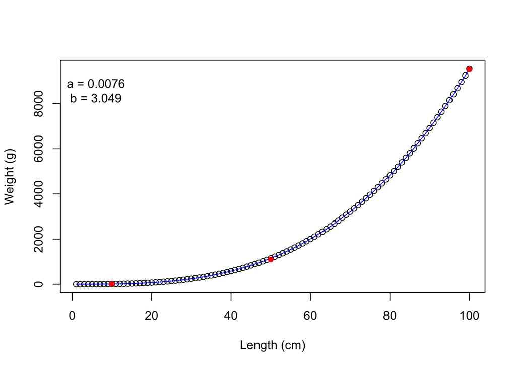

```r
lw_relationship(a = 0.00760, b = 3.049, cv = 0)
points(x = c(10, 50, 100), y = c(8.5, 1100, 9500), col = "red", pch = 16)
```

The values for red points have been acquired using the “Recalculate” button for 10, 50 and 100 cm. The points seem to fit the line within rounding error of the FishBase feature.

**E1.3**

For example:

```r
#' @title Plot length-weight relationship for a species
#' @description The function plots the length-frequency relationship for a (fish) species given the common parameters used for this type of calculation and adds noise to the resulting relationship
#' @param min.length A numeric value giving the minimum length in cm. Should not be negative or larger than \code{max.length}.
#' @param max.length A numeric value giving the maximum length in cm. Should not be negative or smaller than \code{min.length}.
#' @param a A numeric value giving the intercept parameter for the equation (see Details). Typically between 0.1 and 1e-6.
#' @param b A numeric value giving the slope parameter for the equation (see Details). Typically between 2 and 5.
#' @param cv A numeric value giving the coefficience of variation for the noise component in synthetic data generation. Should be given as a proportion (i.e. between 0 and 1).
#' @details The function uses the common formula Weight = a * Length^b to calculate the length-weight relationship. For more information see \href{https://www.fishbase.se/manual/fishbasethe_length_weight_table.htm}{FishBase}.
#' @author Mikko Vihtakari (Institute of Marine Research)
#' @export
```